# atividades_3-5

Natalia Melo

31/05/2022

# Atividade 3

### Acesso a banco de dados abertos

A espécie-alvo será o peixe marinho *Stegastes variabilis*

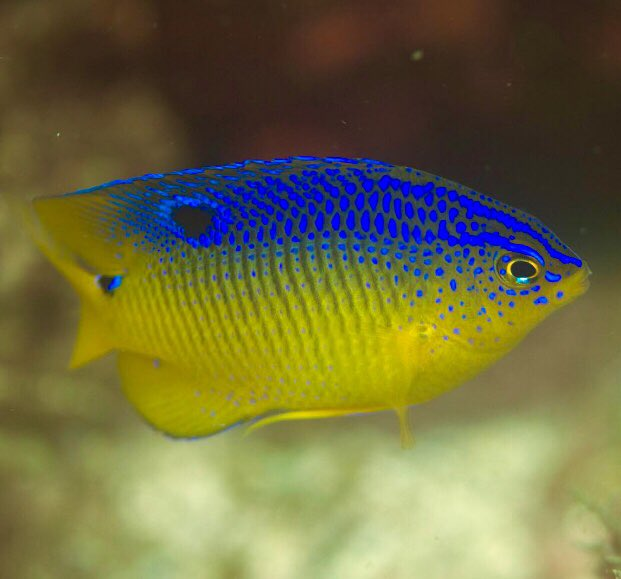

### **GBIF**

```r
# abrindo pacotes

library(tidyverse)
library(rgbif)
library(dplyr)
library(CoordinateCleaner)
library(bdc)
library(ggplot2)
```

```r
#checando função

?occ_data
```

```r
# Baixando ocorrências

donz_gbif <- occ_data(scientificName = "stegastes variabilis",
                      hasCoordinate = TRUE,
                      hasGeospatialIssue=FALSE)
```

```r
# Vendo dimensões

dim(donz_gbif)
```

```r
dim(donz_gbif$data)
```

```
## [1] 500 107
```

```r
# checando campos

donz_gbif$data %>% names
```

```
##   [1] "key"                              "scientificName"
##   [3] "decimalLatitude"                  "decimalLongitude"
##   [5] "issues"                           "datasetKey"
##   [7] "publishingOrgKey"                 "installationKey"
##   [9] "publishingCountry"                "protocol"
##  [11] "lastCrawled"                      "lastParsed"
##  [13] "crawlId"                          "hostingOrganizationKey"
##  [15] "basisOfRecord"                    "occurrenceStatus"
##  [17] "taxonKey"                         "kingdomKey"
##  [19] "phylumKey"                        "classKey"
##  [21] "orderKey"                         "familyKey"
##  [23] "genusKey"                         "speciesKey"
##  [25] "acceptedTaxonKey"                 "acceptedScientificName"
##  [27] "kingdom"                          "phylum"
##  [29] "order"                            "family"
```

[output cut: 39 more lines]

Selecionando variáveis que serão úteis para a validação dos dados e futuras análises, como coordenadas, profundidade, nome da base de dados etc.

```r
donz_gbif1 <- donz_gbif$data %>%
  dplyr::select(scientificName, acceptedScientificName, decimalLatitude, decimalLongitude,
                issues, waterBody, basisOfRecord, occurrenceStatus, rightsHolder,
                datasetName, recordedBy, depth, locality, habitat)
```

Total de 500 ocorrências, no entanto, vamos ver quantas são únicas aplicando a função `distinct` do pacote `dplyr`.

```r
donz_gbif1 <- donz_gbif1 %>%
  distinct()
```

```r
# Checando níveis dos fatores

lapply(donz_gbif1, unique)
```

```
## $scientificName
## [1] "Stegastes variabilis (Castelnau, 1855)"
##
## $acceptedScientificName
## [1] "Stegastes variabilis (Castelnau, 1855)"
##
## $decimalLatitude
##   [1] -12.581289 -12.581595 -12.581883 -20.333822  -8.705033 -23.843822
##   [7]  11.325742 -12.578083 -14.280140  14.781330  14.785620  17.941200
##  [13]  17.934980  18.444940  18.223620  18.462810  18.453720  18.163040
##  [19]  18.165170  18.166370  18.347320  18.350720  18.346520  18.350650
##  [25]  17.897550  17.991160  18.001700  17.888270  17.936570  17.936260
##  [31]  17.964900  17.960930  17.959550  17.934720  17.939370  18.318220
##  [37]  18.357380  18.344030  18.280680  -8.715203  17.895070  17.934570
##  [43]  17.904040  17.915440  18.294590  17.762780  17.773880  17.761500
```

[output cut: 143 more lines]

### Problemas não reportados

```r
#Checar coordenadas válidas
check_pf <-
  bdc::bdc_coordinates_outOfRange(
    data = donz_gbif1,
    lat = "decimalLatitude",
    lon = "decimalLongitude")
```

```
##
## bdc_coordinates_outOfRange:
## Flagged 0 records.
## One column was added to the database.
```

```r
# Checar coordenadas válidas e próximas a capitais
cl <- donz_gbif1 %>%
  select(acceptedScientificName, decimalLatitude, decimalLongitude) %>%
  rename(decimallongitude = decimalLongitude,
         decimallatitude = decimalLatitude,
         scientificName = acceptedScientificName) %>%
  as_tibble() %>%
  mutate(val = cc_val(., value = "flagged"),
         sea = cc_sea(., value = "flagged"),
         capital = cc_cap(., value = "flagged"))
```

```
## Testing coordinate validity
```

```
## Flagged 0 records.
```

```
## Testing sea coordinates
```

```
## Flagged 123 records.
```

```
## Testing country capitals
```

```
## Flagged 11 records.
```

Verificar se as ocorrências estão em terra ou apenas próximas a países insulares.

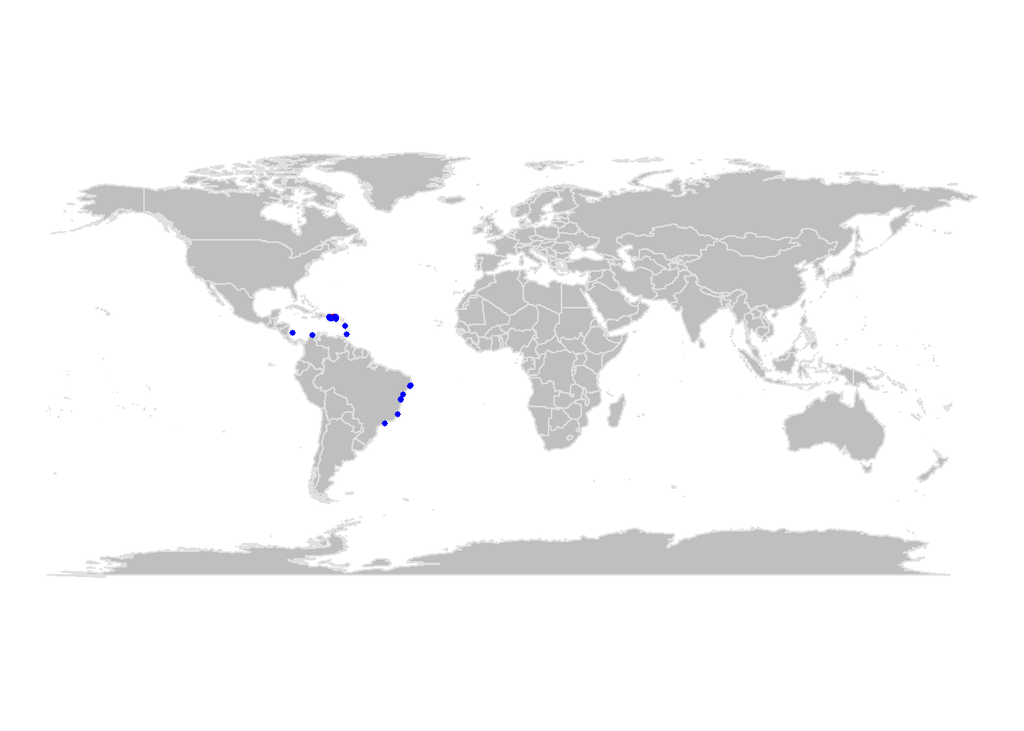

```r
# verificar coordenadas com flags

# capitais (padrão é um raio de 10km)
cl %>%
  rename(decimalLongitude = decimallongitude,
         decimalLatitude = decimallatitude) %>%
  bdc::bdc_quickmap(., col_to_map = "capital")
```

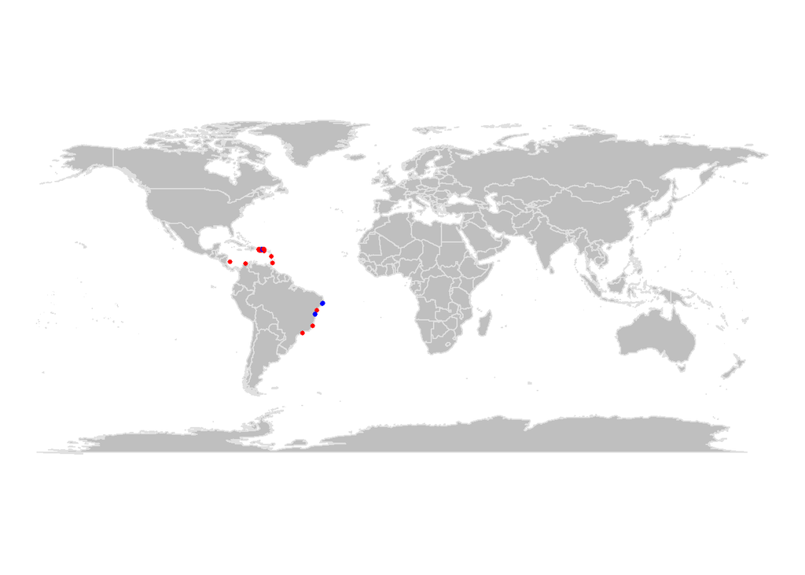

```r
cl %>%
  rename(decimalLongitude = decimallongitude,
         decimalLatitude = decimallatitude) %>%
  bdc::bdc_quickmap(., col_to_map = "sea")
```

Uma maneira fácil de excluir dados em terra é checar a distribuição das ocorrências em relação às regiões oceanográficas indicadas nos dados (`waterBody`).

```r
# investigar niveis suspeitos
donz_gbif1 %>%
  distinct(waterBody) %>%
  pull()
```

```
## [1] NA                   "Northwest Atlantic" "Mar Caribe"
```

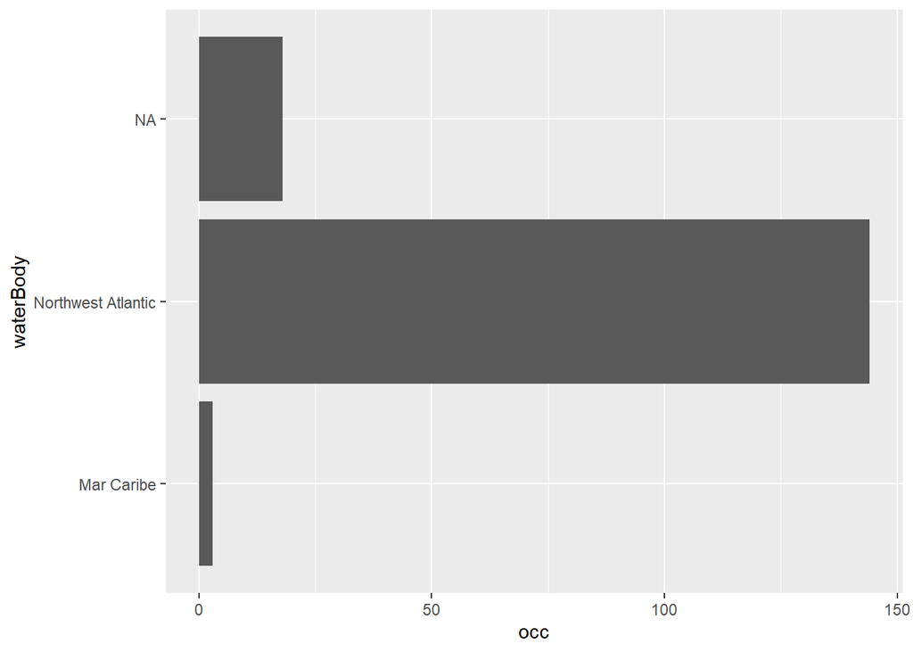

```r
# waterBody
donz_gbif1 %>%
  group_by(waterBody) %>%
  summarise(occ = length(scientificName)) %>%
  ggplot(aes(occ, y=waterBody)) +
  geom_bar(stat = 'identity')
```

Depois de colher informações sobre o táxon no **Fishbase**, as ocorrências indicadas são válidas e não precisam passar pela etapa de exclusão de dados suspeitos.

### Próximo passo é visualizar os pontos no mapa

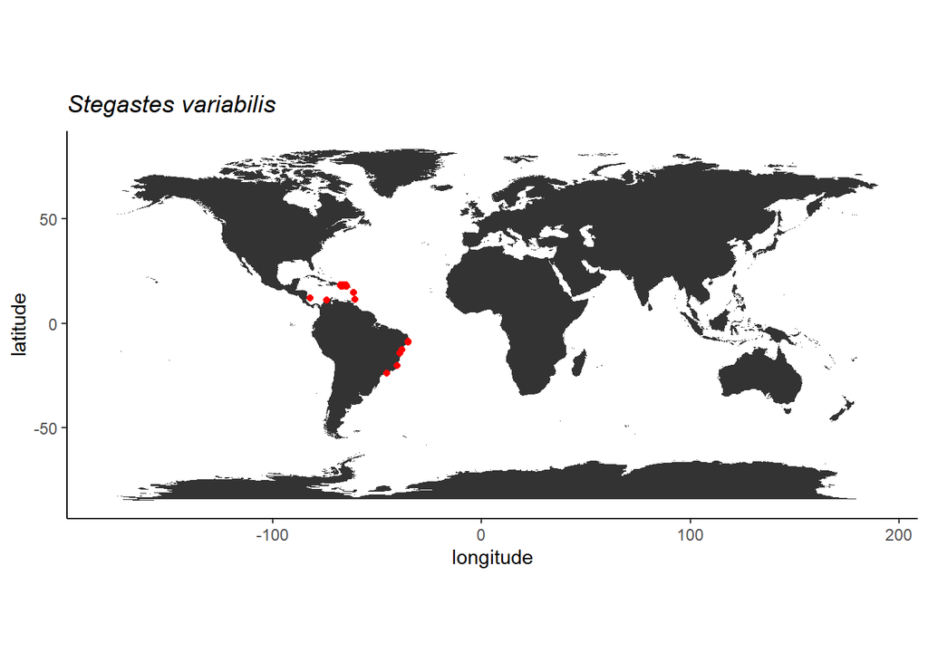

```r
library(ggmap)
library(maps)
library(mapdata)

world <- map_data('world')

# checar pontos

ggplot() +
  geom_polygon(data = world, aes(x = long, y = lat, group = group)) +
  coord_fixed() +
  theme_classic() +
  geom_point(data = donz_gbif1, aes(x = decimalLongitude, y = decimalLatitude), color = "red") +
  labs(x = "longitude", y = "latitude", title = expression(italic("Stegastes variabilis")))
```

Checando profundidade, visto que no **Fishbase** o intervalo de profundidade para a espécie varia entre 0-30m.

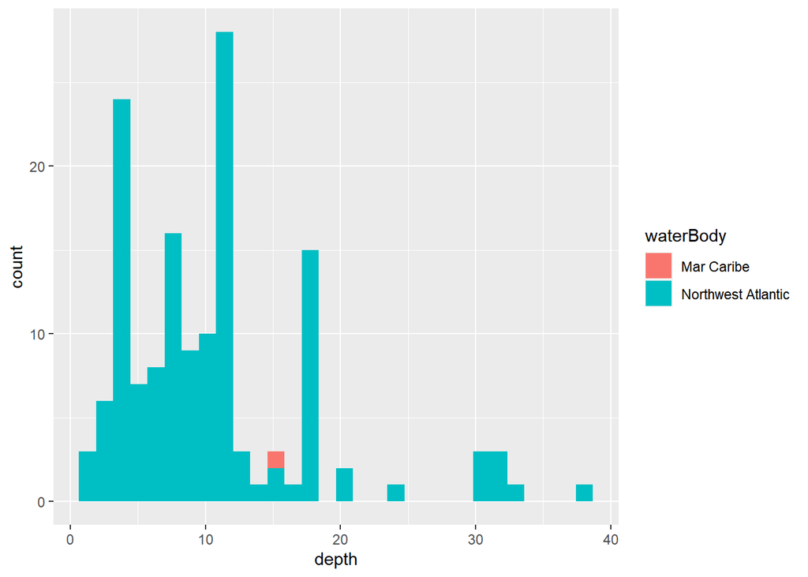

```r
# checar profundidade
donz_gbif1 %>%
  ggplot(aes(x = depth, fill = waterBody)) +
  geom_histogram()
```

```r
donz_gbif_ok <- donz_gbif1
```

## OBIS

Agora vamos fazer os mesmos procedimentos com os dados do **OBIS**, utilizando o pacote `robis` e a função `occurrence` deste pacote.

```r
library(robis)
```

```r
# baixando as ocorrências
donz_obis <- robis::occurrence("Stegastes variabilis")
```

```r
# checando os dados
names(donz_obis)
```

```
##   [1] "infraphylum"                      "country"
##   [3] "date_year"                        "habitat"
##   [5] "references"                       "scientificNameID"
##   [7] "scientificName"                   "dropped"
##   [9] "gigaclassid"                      "aphiaID"
##  [11] "language"                         "decimalLatitude"
##  [13] "subclassid"                       "type"
##  [15] "gigaclass"                        "infraphylumid"
##  [17] "phylumid"                         "familyid"
##  [19] "occurrenceStatus"                 "basisOfRecord"
##  [21] "terrestrial"                      "modified"
##  [23] "maximumDepthInMeters"             "id"
##  [25] "parvphylum"                       "order"
##  [27] "dataset_id"                       "minimumElevationInMeters"
##  [29] "stateProvince"                    "decimalLongitude"
```

[output cut: 62 more lines]

```r
donz_obis1 <- donz_obis %>%
  dplyr::select(scientificName, decimalLatitude, decimalLongitude, bathymetry,
                flags, waterBody, basisOfRecord, occurrenceStatus, rightsHolder,
                datasetName, recordedBy, depth, locality, habitat) %>%
  distinct()

# checando problemas reportados (flags)
donz_obis1 %>%
  distinct(flags)
```

```
## # A tibble: 7 x 1
##   flags
##   <chr>
## 1 <NA>
## 2 NO_DEPTH
## 3 DEPTH_EXCEEDS_BATH
## 4 NO_DEPTH,ON_LAND
## 5 ON_LAND
## 6 ON_LAND,DEPTH_EXCEEDS_BATH
## 7 ON_LAND,NO_DEPTH
```

```r
# check NA em datasetName
donz_obis1 %>%
  filter(!flags %in% c("no_depth,on_land", "on_land", "on_land,depth_exceeds_bath", "depth_exceeds_bath,on_land"),
         is.na(datasetName)) %>%
  distinct(waterBody)
```

```
## # A tibble: 12 x 1
##    waterBody
##    <chr>
##  1 <NA>
##  2 South Atlantic
##  3 Gulf of Mexico
##  4 Atlantic
##  5 Central America
##  6 South America
##  7 Caribbean Sea
##  8 North America
##  9 Mar Caribe
## 10 Atlantic Ocean
## 11 atlantique
## 12 Caribe
```

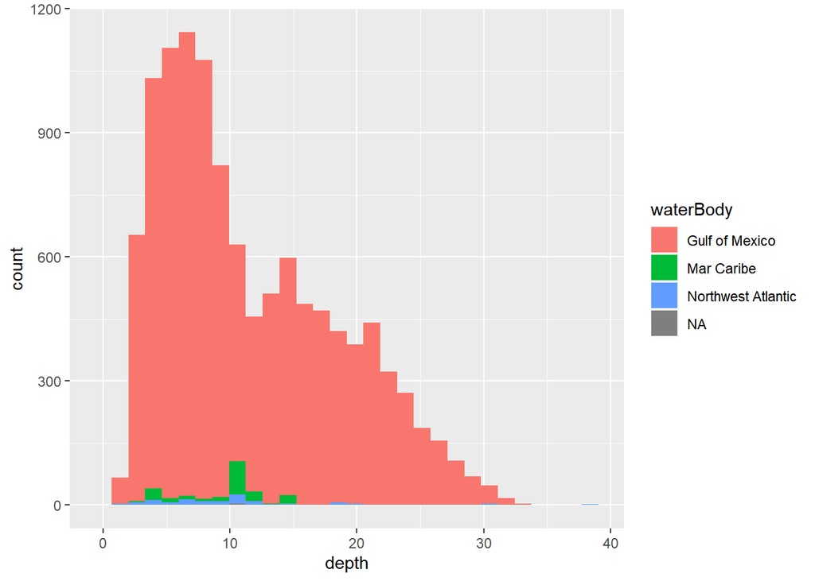

```r
# profundidade ok
donz_obis1 %>%
  filter(!flags %in% c("no_depth,on_land", "on_land", "on_land,depth_exceeds_bath", "depth_exceeds_bath,on_land"),
         !is.na(datasetName)) %>%
         #!waterBody %in% c("North America", "North America Atlantic", "atlantique")) %>%
  ggplot(aes(x = depth, fill = waterBody)) +
  geom_histogram()
```

```r
# checando niveis
donz_obis1 %>%
  filter(!flags %in% c("no_depth,on_land", "on_land", "on_land,depth_exceeds_bath", "depth_exceeds_bath,on_land"),
         !is.na(datasetName)) %>%
         #!waterBody %in% c("North America", "North America Atlantic", "atlantique")) %>%
  lapply(., unique)
```

```
## $scientificName
## [1] "Stegastes variabilis"
##
## $decimalLatitude
##    [1]  24.724030  24.722267  24.543210  25.176030  24.606880  24.657820
##    [7]  24.639517  24.623333  24.669000  24.720733  24.708850  24.719917
##   [13]  24.708333  24.722630  24.454133  24.766317  24.506033  24.582333
##   [19]  25.136890  24.989260  24.596030  24.647933  24.643710  24.507217
##   [25]  24.674770  25.215883  18.262670  24.473250  24.446390  24.568250
##   [31]  24.668450  24.652067  24.603867  24.641430  17.773880  25.142583
##   [37]  24.692167  24.514450  25.626667  24.774610  24.682810  24.561500
##   [43]  24.668283  25.246000  24.499633  24.501383  24.673567  25.105780
##   [49]  24.602820  25.361720  24.667700  24.674067  24.442567  24.904070
##   [55]  24.656033  24.666420  24.631483  24.667730  24.563083  24.677017
##   [61]  24.662567  24.591560  24.502967  24.677500  24.653967  24.724833
```

[output cut: 3199 more lines]

```r
# ok
donz_obis_ok <- donz_obis1 %>%
  filter(!flags %in% c("no_depth,on_land", "on_land", "on_land,depth_exceeds_bath", "depth_exceeds_bath,on_land"),
         !is.na(datasetName),
         !waterBody %in% c("NA"))
```

Checando as ocorrências no mapa

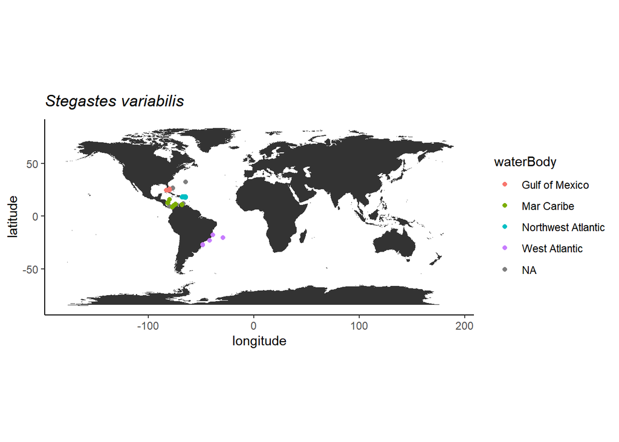

```r
# check
ggplot() +
  geom_polygon(data = world, aes(x = long, y = lat, group = group)) +
  coord_fixed() +
  theme_classic() +
  geom_point(data = donz_obis_ok, aes(x = decimalLongitude, y = decimalLatitude, color = waterBody)) +
  labs(x = "longitude", y = "latitude", title = expression(italic("Stegastes variabilis")))
```

Tudo ok!

Por fim, vamos unir todas as ocorrências (GBIF e OBIS), checar se existem duplicatas e plotar o resultado final.

```r
#Unir gbif e obis

# ver diferencas
setdiff(names(donz_gbif_ok), names(donz_obis_ok))
```

```
## [1] "acceptedScientificName" "issues"
```

```r
setdiff(names(donz_obis_ok), names(donz_gbif_ok))
```

```
## [1] "bathymetry" "flags"
```

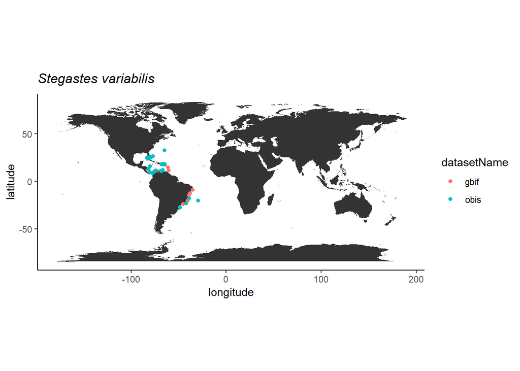

```r
all_data <- bind_rows(donz_gbif_ok %>%
                        mutate(repo = paste0("gbif", row.names(.))),
                      donz_obis_ok %>%
                        mutate(repo = paste0("obis", row.names(.)))) %>%
  column_to_rownames("repo") %>%
  dplyr::select(decimalLongitude, decimalLatitude, depth) %>%
  distinct() %>%
  rownames_to_column("occ") %>%
  separate(col = "occ", into = c("datasetName", "rn"), sep = 4) %>%
  mutate(scientificName = "Stegastes variabilis") %>%
  dplyr::select(-rn)


# mapear ocorrencias
ggplot() +
  geom_polygon(data = world, aes(x = long, y = lat, group = group)) +
  coord_fixed() +
  theme_classic() +
  geom_point(data = all_data, aes(x = decimalLongitude, y = decimalLatitude, color = datasetName)) +
  #theme(legend.title = element_blank()) +
  labs(x = "longitude", y = "latitude", title = expression(italic("Stegastes variabilis")))
```

Baixando os dados já tratados

```r
write.csv(all_data, "occ_GBIF-OBIS_par_hepa.csv", row.names = FALSE)
```